# The FAIR Guiding Principles for scientific data management and stewardship

Ambra Perugini

# Why FAIR?

- Growing demands for **transparency** and **reproducibility**
- Data is often hard to find, access, interpret, or reuse
- FAIR principles offer a structured solution

> “FAIR = Findable, Accessible, Interoperable, Reusable”

[Article: The FAIR Guiding Principles for scientific data management and stewardship](https://www.nature.com/articles/sdata201618)

# Overview of FAIR

- A set of guiding principles
- Applicable across disciplines
- Aiming at **machine-readability** and referring to **data stewardship**

# Findable

**Key ideas:**

- Assign globally unique and persistent identifiers (PIDs)
- Metadata should be rich and indexed in searchable resources

**Example in practice:**

- Use DOIs for datasets
- Tag datasets with relevant keywords and metadata

# Accessible

**Key ideas:**

- Use standardized protocols (e.g., HTTP)
- Metadata remains accessible even if data is restricted

**Example in practice:**

- Publish metadata openly even if data is sensitive (e.g., clinical trials)
- Use data repositories (e.g., OSF, Zenodo)

# Interoperable

**Key ideas:**

- Use standardized vocabularies and formats
- Data should interoperate with tools and other datasets

**Example in practice:**

- Store data in open formats (CSV, JSON)
- Use standardized variable naming

# Reusable

**Key ideas:**

- Clear data usage licenses
- Rich metadata describing context, provenance

**Example in practice:**

- Add a Creative Commons license
- Include documentation, codebooks, analysis scripts

# Understanding Data Licenses

## Why it Matters

- Licenses clarify what others can legally do with your data or code
- No license? Others may not be able to reuse your work—even for research

# Common License Types

## Creative Commons (CC) — for datasets, docs, media:

- **CC0 (CC0-1.0)** — No rights reserved, public domain
- **CC-BY (CC-BY-4.0)** — Attribution required
- **CC-BY-SA (CC-BY-SA-4.0)** — Attribution + same license

**Best for data sharing:** CC0 or CC-BY

# Open Source Licenses (GitHub-Friendly)

These are commonly used on GitHub for code:

- **MIT** — Simple, permissive, attribution only
- **Apache-2.0** — MIT + patent rights
- **GPL-3.0** — Must share derivative code with same license
- **BSD-2-Clause** and **BSD-3-Clause** — Similar to MIT, widely used
- **MPL-2.0** — File-level copyleft, flexible
- **Unlicense** — Public domain equivalent

**Most GitHub projects use:** MIT, Apache-2.0, or GPL-3.0

# How to License Your Work

- Choose based on how open you want reuse to be
- Add a short `README` or metadata tag

**Example:**

```
This dataset is licensed under CC-BY 4.0.
You are free to share and adapt it, provided you give appropriate credit.
```

Or for code:

```
MIT License
Copyright (c) 2025 Your Name
Permission is hereby granted, free of charge, to any person obtaining a copy...
```

# FAIR in Psychology

- Improves **replicability** and **meta-analyses**
- Facilitates **collaboration**
- Encourages **better documentation** and data curation

# First steps to become more FAIR

- Use data repositories (e.g., OSF, Dataverse)
- Adopt metadata standards (e.g., DDI, Dublin Core)
- Publish protocols and code
- Provide clear licenses

# Tools and Resources

- [FAIRsharing.org](https://fairsharing.org/)
- [GitHub Pages Licensing Guide](https://docs.github.com/en/github/creating-cloning-and-archiving-repositories/licensing-a-repository)
- [Open Science Framework](https://osf.io/)
- [Creative Commons Licenses](https://creativecommons.org/)
- [ChooseALicense.com](https://choosealicense.com/)
- [Zenodo](https://zenodo.org/)

# How are we doing?

## The daily costs of workaholism

- **Findable**: *DOI 10.17605/OSF.IO/AWBXJ*
- **Accessible**: [*https://osf.io/awbxj/*](https://osf.io/awbxj/)
- **Interoperable**: *.csv file*
- **Reusable**: *CC-By Attribution 4.0 International, datadictionary, readme file, scripts*

(half on github and half on osf?)

## Domain-level differences in skills and traits change goals

- **Findable**: *DOI 10.17605/OSF.IO/SWDC2*
- **Accessible**: [*https://osf.io/swdc2/*](https://osf.io/swdc2/)
- **Interoperable**: *.xlsx instead of .csv (also for codebook)*
- **Reusable**: *CC-By Attribution 4.0 International, codebook (ie. datadictionary), readme file, scripts*

## Predictions under sleep restriction

- **Findable**: *DOI 10.17605/OSF.IO/6FXMH*
- **Accessible**: https://osf.io/6fxmh/
- **Interoperable**: *both .csv and .xlsx*
- **Reusable**: *CC-By Attribution 4.0 International, renv* *(helps you create reproducible environments for your R projects), but absence of datadictionary and readme*

## Auditory and cognitive performance in elderly musicians and nonmusicians

- **Findable**: https://doi.org/10.6084/m9.figshare.5402527.v1, *Keywords*
- **Accessible**: [*figshare*](https://figshare.com/s/0af2a3aeb7860d1c6bbc?file=9306271)
- **Interoperable**: *.xlsx instead of .csv*
- **Reusable**: *CC-By Attribution 4.0 International, absence of ReadMe and datadictionary*

## Dyslexia Polygenic Scores Show Heightened Prediction of Verbal Working Memory and Arithmetic

The full GWAS summary statistics for the 23andMe discovery data set are available through 23andMe to qualified researchers under an agreement with 23andMe that protects the privacy of the 23andMe participants. Datasets will be made available at no cost for academic use. Please visit https://research.23andme.com/collaborate/#dataset-access/ for more information and to apply to access the data.

# Best Practice

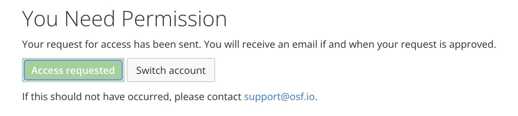